# Teaching case: growth of restaurants as economic thrivingness indicator

PPUA 5262: Big data for cities Northeastern University

# Overview

**Characterizing living communities through data is a challenging task**, as their ever-changing and multifaceted nature resists simple explanations. Deterministic approaches, which treat data as providing absolute conclusions, often lead to oversimplifications that risk misrepresenting or even stigmatizing them. Yet, **data can also serve as a powerful tool** —when used not to obtain definitive answers, but as a tool **to construct broader and more nuanced understandings of community dynamics**. By transforming raw variables into **meaningful proxies for real-world phenomena**, data can help illuminate the multifaceted realities of urban life. Over the course of the semester, we explored Boston’s food establishment inspection records with the goal of deriving insights that extend beyond regulatory outcomes, seeking to better understand the neighborhoods and communities reflected in the data.

Restaurants are more than places to eat; they are critical spaces for social interaction, cultural expression, and economic activity. **The growth or decline of restaurants often reflects broader local dynamics**. An increase in restaurant numbers can signify economic vitality, community vibrancy, and regional or local investment in the area, with decisions to open establishments informed by considerations of potential return on investment, safety, accessibility, and developmental promise. Conversely, a decline may point to economic hardship, shifting demographics, or diminishing neighborhood appeal. **Tracking restaurant growth rates offers a valuable perspective on these changes, revealing patterns of economic health and social transformation**. By examining the history of restaurant openings and closings, we can provide valuable insights to community members, stakeholders, and policymakers, helping them better understand the forces shaping urban communities over time.

The **food establishment inspections dataset**, while not explicitly designed to track restaurant openings and closures, **offers valuable insights for this purpose**. By recording annual inspections for each establishment, **it provides an approximate count of how many restaurants were operational in a given year**. Though a single year’s absence of an inspection does not pinpoint exactly when a restaurant opened or closed, it serves as a reasonable proxy for tracking activity over time. Additionally, the inclusion of geographic data for each business enables flexibility in **aggregating information at various levels**, allowing us to analyze trends in restaurant operations across neighborhoods, districts, and the city as a whole.

**In this post, we will demonstrate how the original dataset can be transformed to derive various measures of the number of operating businesses across different geographical levels**. These measures can take the form of absolute counts, growth rates compared to the previous year, or trends relative to a rolling average over multiple years. Additionally, we will introduce supplementary variables that can be used to cross-analyze with the primary metric—the number of restaurants—to explore potential relationships and deepen our understanding of the dynamics at play. **The objective of this work is to evaluate whether the developed measure** serves merely as a straightforward count of operating businesses or if it **holds potential as a proxy for broader dynamics within urban communities**. By analyzing this metric, we aim to determine whether it can reveal insights that go beyond its immediate interpretation, offering a deeper understanding of the economic, social, and spatial transformations reflected in the dataset.

It is noteworthy that this work was conducted as **part of the Big Data for Cities course**, which this year **focused on analyzing the Common Senses study area**. Common SENSES is a collaborative research project between Northeastern, communities in Roxbury and Dorchester, and the City of Boston, aimed at supporting Environmental Justice action in the neighborhoods along Blue Hill Avenue, from Dudley Commons to Franklin Park.

# Measurement Construction

The **food establishment inspections dataset** includes records of inspections conducted in Boston since 2006. Each record typically corresponds to a single violation, though some entries represent the overall inspection outcome (e.g., no violations or incomplete inspections). As of September 13, 2024, the dataset comprises **807,805 records** and includes **27 variables** spanning business administration, establishment location, inspection details, and violation-specific information. Variables include identifiers, spatial and temporal data, categorical values (such as violation severity or inspection outcomes), and free-text fields containing descriptions or inspector comments. Fields that do not apply to specific records—such as violation details for inspections without violations—are marked as NA (empty).

**Food establishments in Boston are primarily concentrated in high-density areas** like Downtown and Back Bay, while lower-density neighborhoods to the west and south have fewer restaurants. Interestingly, restaurants are not evenly distributed across the city but **tend to cluster along major roads and avenues**. This clustering pattern makes it challenging to use small spatial boundaries, such as census blocks or tracts, as analytical units. These boundaries, often defined by street axes, can split restaurants located on opposite sides of the same street into different spatial units, despite being part of the same cohesive cluster. Even more, in some cases, these small units may not contain any restaurants at all, further complicating analysis.

[interactive chart not shown]

fig.1: distribution of establishments in Boston

**Spatial aggregation unit**

For this work, **we use clusters of restaurants as our primary spatial unit of aggregation**. However, **we also use the neighborhood level** to obtain insights across Boston. It is important to highlight that the construction of our measures is analogous across various scales of aggregation. These clusters are not provided in the dataset by default but must be generated.

The process is relatively straightforward. First, we extract the variables `licenseno` (establishment license number) and `location` (coordinates of the establishment in the Mercator system) from the dataset. From the `location` variable, we create two new columns by splitting the data into `latitude` and `longitude`. Next, we group the data by `licenseno` and slice the aggregation to retain a single occurrence for each establishment.

**Temporal aggregation unit**

**For the temporal aggregation, we chose a yearly time unit** since inspections are conducted at least once a year, with additional follow-ups triggered when compliance issues arise. To achieve this, we used the variable `resultdttm` (inspection date and time). Using the *lubridate* package, we converted `resultdttm` from a string to a datetime object and extracted the year as a new column named `result_year`.

**Measurement**

With the spatial and temporal aggregation units defined, we can now proceed to **create the measures** related to the number of businesses inspected annually.

The first step involves **ensuring unique observations**. To do this, we group the dataset by `licenseno` (unique restaurant identifier), `result_year` (temporal unit), and `cluster` (spatial unit). After grouping, we slice the data to retain a single occurrence per group, which guarantees one row per restaurant license per year and cluster. For efficiency, we keep only these three columns, reducing memory usage while preserving the essential information.

Next, we **count the number of establishments inspected each year for every cluster**. This is done by grouping the data again, this time using only the `result_year` and `cluster` variables, and summarizing the data as a count. The resulting dataset contains one row per cluster per year, with a column labeled `count` representing the total number of establishments inspected annually. This count serves as a proxy for the number of operating businesses in each spatial and temporal unit.

While the absolute number of establishments is a straightforward measure, it often tells only part of the story. To better understand dynamics over time, **we also calculate the growth rate, which captures changes in the number of establishments relative to previous years**. Recognizing that a single year might be atypical (e.g., due to events like the pandemic), we base this measure on the average number of establishments over the previous n years.

The growth rate is calculated as **the adjusted log growth rate**, which **accounts for differences in scale and mitigates the effect of extreme changes**. Specifically, for a cluster *c* in year *y*, the growth rate is defined as:

$$gr_{c,y} = log(N_{c,y} + d) -
log(mean(N_{c,y-1}, N_{c,y-2}, ..., N_{c,y-n}) + d),$$

where:

$N_{c,y}$: the number of inspected restaurant in cluster $c$, in year $y$.

$d$: a constant that helps mitigate the impact of absolute differences in smaller values.

Is interesting to note that, when setting $n = 1$, we are just getting the growth rate metric in comparison with the previous year.

The first step in calculating the growth rate metric with our data is to **establish a baseline for comparison**. This involves averaging the number of establishments in the `count` for each cluster over the previous *n* years. For each year within the study period, we filter the data to include only the counts from the prior *n* years, grouping by `cluster` to calculate the mean. This value, stored as `base_count`, serves as a reference point for evaluating growth. To avoid issues with missing data, any spatial units with no `base_count` are assigned a value of 0. Note that counts from the *n* years before the start of the study period are necessary to calculate baselines for the initial years of analysis.

The second step is to **merge these baseline values into the main dataset containing the annual counts**. Using a left join, the auxiliary dataframe with `base_count` is matched to the main counts dataframe by `cluster` and `result_year` columns. After the merge, rows corresponding to the *n* years preceding the study period are removed since their only purpose was to establish baselines for the initial years and are no longer needed in the analysis.

Finally, **the growth rate metric itself is calculated**. To adjust for scale differences across spatial units and mitigate the effect of extreme values, we introduce a constant *d*, typically set to 5. For each year and cluster, the adjusted growth rate is computed as the difference between the natural logarithms of `count` plus *d* and `base_count` plus *d*. The resulting value, stored in a new column called `gr_score`, provides a smoothed and interpretable measure of growth that reflects changes in the number of establishments relative to the baseline established from the prior *n* years.

# Analysis

**As a first step in our analysis, we set our focus on the neighborhood level**. This scale offers a manageable number of units for comparison and typically includes major roads and key intersections within each area. Boston neighborhoods vary widely in size and shape, with Common Senses—despite being smaller than the overlapping neighborhoods of Roxbury and Dorchester—remaining comparable in scale to many others across the city. To merge the establishments with these boundaries, we performed a spatial join between the points representing each establishment and the neighborhood geometries sourced from the Boston Data Portal.

Given the variations in neighborhood scales, raw counts alone make it difficult to draw meaningful conclusions. To address this, **we use the adjusted log growth rate developed earlier** as our primary metric. By comparing each year’s restaurant count to the average of the previous five years, this measure provides a form of momentum to the metric, capturing changes in a way that emphasizes trends over time. For instance, a sharp decline followed by a modest recovery would still register as negative in both years, reflecting the gradual nature of the rebound. This is particularly relevant for the post-2020 period, during which many neighborhoods saw a sharp decline in inspected restaurants. For neighborhood-level analysis, we set the constant *d* to 0, as the relatively large number of establishments per neighborhood makes its effect negligible.

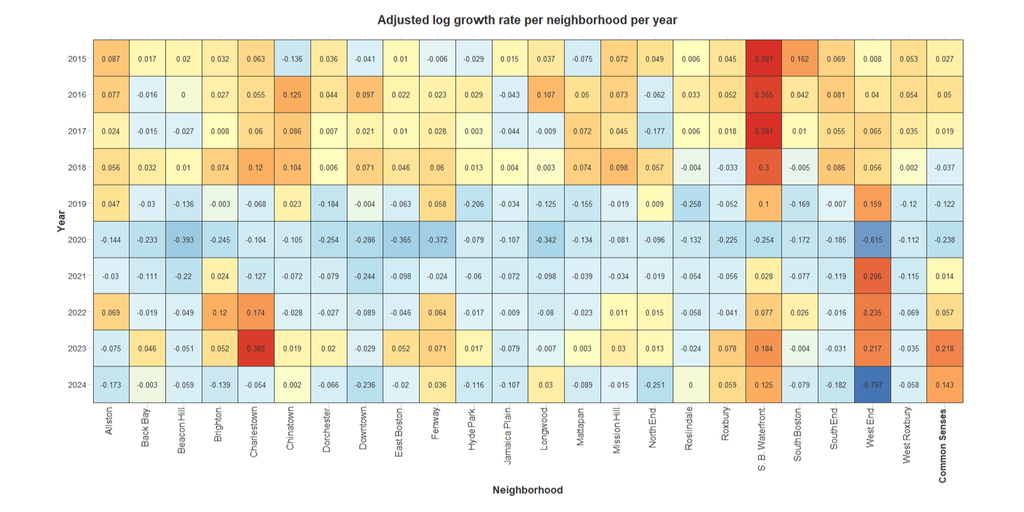

fig.2: measurement score per neighborhood

**The analysis of our metric** using neighborhoods as the spatial unit and years as the temporal unit **provides valuable insights into growth patterns in Boston’s restaurant industry**.

Apart from the atypical dynamics of the pandemic year, **a few neighborhoods exhibited remarkable levels of restaurant growth that deviate from the typical patterns observed elsewhere in Boston**. For instance, South Boston Waterfront and the West End experienced sustained restaurant growth over the past decade, interrupted only temporarily by the pandemic. While the West End registered another dip in 2024, this may reflect delayed inspections rather than an actual downturn. Similarly, Charlestown’s sharp rise in new restaurants in 2023 suggests it may be following a growth trajectory akin to that seen in the South Boston Waterfront around 2015.

However, these neighborhoods are **outliers**, with their growth patterns **largely driven by planned redevelopment initiatives** rather than the organic economic and social dynamics influencing most Boston neighborhoods. For the purposes of this analysis, we focus on areas where growth patterns reflect more gradual or everyday neighborhood forces, as opposed to those shaped predominantly by policy-driven structural redevelopment.

**Among neighborhoods with trends reflective of typical dynamics, some have yet to return to their pre-pandemic levels**. Beacon Hill, Downtown, Jamaica Plain, and West Roxbury, for example, continue to report restaurant counts below their baseline in the years following the pandemic. Longwood and Roslindale have shown relative stability, with neither significant gains nor losses recently. Even so, their current counts remain considerably below what they were before 2019.

**Conversely, several neighborhoods have demonstrated notable recovery since the pandemic**. Brighton, Fenway, Mission Hill, North End, and Roxbury stand out as areas with significant post-pandemic rebounds. The Common Senses study area is particularly noteworthy in this group, having achieved an exceptionally swift recovery by 2021, reaching pre-pandemic levels and recording its highest number of inspected restaurants in a decade by 2023.

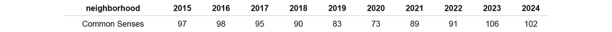

The previously discussed heatmap provides invaluable insights into historical trends across neighborhoods. However, it lacks the spatial granularity needed to fully understand these patterns across Boston. To address this limitation, **choropleth maps serve as a valuable complement, offering the geographic context necessary to interpret these dynamics**.

Given that choropleth maps are less suited to illustrating temporal evolution—unless we were to plot a separate map for each year, which would still make comparisons challenging—we selected two key years to analyze in detail. The first is 2020, which, as previously discussed, stands out as an atypical year marked by an overall decrease in restaurant activity due to the pandemic. The second is 2023, the most recent complete year in our dataset, providing a comparative perspective on how the distribution of restaurant growth across neighborhoods has evolved.

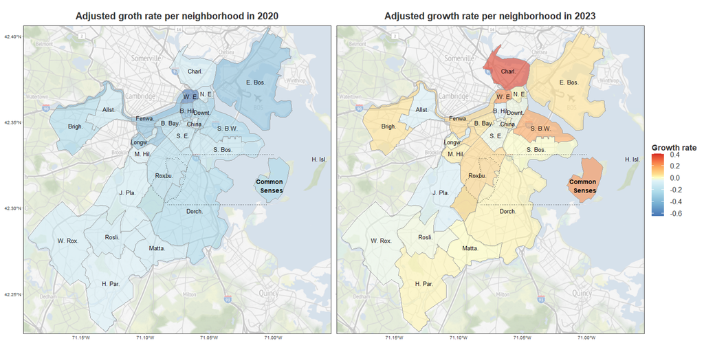

fig.3: measurement score across Boston

The differences between the two choropleth maps are striking. **The 2020 map is dominated by negative values**, reflecting the widespread decline in restaurant activity during the pandemic. In contrast, **the 2023 map exhibits far greater variability**, with both positive and negative growth rates, signaling a more complex and differentiated recovery across neighborhoods.

Some patterns identified earlier in the heatmap are still evident in these spatial plots. **The neighborhoods previously identified as outliers continue to exhibit the highest growth rates in 2023**. For instance, the South Boston Waterfront and the West End show growth rates around 0.2, while Charlestown stands out with a particularly high growth rate of 0.365, as previously highlighted. Charlestown’s sharp increase is likely driven by its recent surge in new restaurants, which means its five-year rolling average baseline remains relatively low, amplifying its growth score.

Notably, **in 2023, the Common Senses study area**, overlapping with parts of Roxbury mainly, and Dorchester, **shows a growth rate comparable to the aforementioned outliers**. However, Roxbury itself, while still positive, exhibit much lower score. This suggests that the portion of Roxbury overlapping with the Common Senses area is the primary driver of the growth observed there. The dynamics within the Common Senses study area warrant further attention and will be revisited later in this analysis.

Focusing on the 2020 choropleth map, it provides a spatial dimension to the earlier insights regarding neighborhoods with the steepest decline in restaurant activity. West End, Beacon Hill, Downtown, and East Boston—neighborhoods that experienced significant downturns—are located in close proximity to each other. Similarly, Fenway and Longwood also stand out for their sharp declines, with only Back Bay spatially separating them from the previously mentioned group. This clustering suggests that **neighborhoods near the central parts of the city were disproportionately impacted during the pandemic**.

In contrast, **neighborhoods further from the city center experienced a much smaller decline during the same period**. Hyde Park, West Roxbury, Roslindale, Mattapan, Jamaica Plain, Mission Hill, and Allston are all among those that showed the lowest decreases relative to their five-year rolling averages. These neighborhoods also did not feature prominently among those with the highest growth rates in 2023, suggesting a more stable historical trend.

The **relationship between proximity to city center and the degree of decline in restaurant growth rates during the pandemic** suggested by the 2020 choropleth is are visually striking. While this pattern is visually perceivable, **relying on visual interpretation alone is insufficient** to assert the existence of such a relationship. What might appear to be a clear trend could, in fact, be a visual illusion. To substantiate the pattern, we must evaluate its statistical significance—that is, assess the likelihood of observing such a pattern, or one of similar strength, purely by chance.

To test this hypothesis, **we analyze the correlation between two variables**: the relative location within Boston and the growth rate score during 2020. As a proxy for geographical location, we use the distance of each unit of analysis to Downtown. However, this approach raises a methodological question: how do we best define a neighborhood’s distance to Downtown? Neighborhoods in Boston vary significantly in size and shape. Some may have portions very close to Downtown and others much farther away, then different parts of the same neighborhood might exhibit varying trends.

To address these concerns, **we base our analysis on the clustering approach** described earlier in this work. By aggregating restaurants into spatial clusters with at least three establishments in a single year, we create a more precise unit of analysis. Each cluster’s distance to Downtown is measured from its centroid, ensuring that all establishments within the cluster are spatially close to this central point.

[interactive chart not shown]

fig.4: distribution of clusters across Boston

**The results of the clusterization process**, as visualized on the map, **reveal the varying scales and characteristics of the clusters generated**. Since the algorithm relies on a density-based approach, the resulting clusters naturally differ in size and extension. Some clusters contain a high number of establishments, reflecting areas with significant restaurant density, while others are smaller, meeting the minimum threshold of three establishments. Similarly, the spatial arrangement of clusters varies—some clusters are tightly packed in high-density areas, while others are more dispersed, reflecting areas where restaurants are fewer but still close enough to be grouped within the same cluster.

Despite these variations, the algorithm performed effectively, identifying and associating restaurants spread throughout Boston in a manner that aligns with observable patterns in the city’s spatial layout. By grouping establishments based on their proximity, the clustering process offers a nuanced and data-driven framework for our correlation analysis, providing richer insights than would have been possible with coarser spatial units like neighborhoods.

Using the clusters as our primary units of analysis, we proceed to **explore the relationship between their proximity to downtown Boston and their restaurant growth patterns during 2020**. For each cluster, the adjusted log growth rate metric is calculated, comparing the number of establishments in 2020 to the rolling average of the five preceding years. This measure provides a normalized perspective on how restaurant activity within each cluster was affected during the pandemic.

To complement this metric, we determine the spatial relationship of each cluster to downtown Boston. Specifically, the distance from each cluster’s centroid to the centroid of the downtown neighborhood is calculated. This approach ensures consistency across clusters, as the centroid represents the central location of the establishments grouped within each cluster. These two variables—the growth rate and the distance to downtown—form the basis of our subsequent correlation analysis, offering a means to **quantify and assess the potential relationship between geographic location and restaurant performance during the pandemic**.

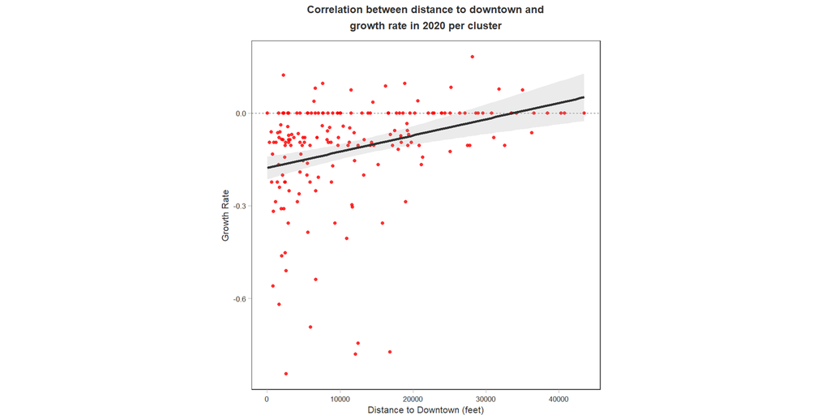

fig.5: correlation between measure and cluster location

**The correlation analysis reveals a statistically significant positive correlation** of 0.315 between the distance to downtown and the growth rate metric for 2020. This relationship suggests that approximately 10% of the variability in restaurant growth during the pandemic year can be explained by proximity to the city center. While the correlation is relatively weak, indicating that many other factors influence the growth rate, the result is noteworthy. **Given how simplistic the distance-to-downtown variable is, its ability to reveal this spatial pattern is both surprising and meaningful, offering a lens into broader trends.**

|  | Pearson.s.correlation | P.value |
| --- | --- | --- |
| Correlation between the growth rate and the distance to downtown | 0.315 | 1.5e-05 |

However, it’s important to recognize that **distance to downtown serves merely as a proxy for uncovering deeper spatial dynamics**. We do not propose that geographic proximity alone dictates whether a restaurant thrives or struggles during challenging periods like the pandemic. Instead, this measure highlights a more profound and structural pattern. Neighborhoods closer to downtown often feature dense restaurant clusters concentrated in small areas, such as a single block or even a single building. Examples include the airport in East Boston, TD Garden in the West End, and Fenway Park. These clusters are often designed to serve transient populations—visitors attending events, traveling through, or exploring the city. Consequently, during an atypical year like 2020, when these attractions were closed or operating at reduced capacity, restaurants in these areas faced significant challenges.

In contrast, neighborhoods further from downtown tend to feature smaller, more dispersed clusters of restaurants spread across one or two blocks. While many of these establishments are situated along major avenues to attract passersby, their customer base is predominantly local. These restaurants often rely on serving their immediate communities, making them more resilient to disruptions in visitor traffic. This distinction in the spatial distribution and primary clientele of restaurants provides critical insights into the differing impacts of the pandemic across Boston’s neighborhoods.

As a final step in our analysis, we turn our attention to the **Common Senses study area**. The clusterization process identified thirteen distinct clusters within this region, revealing a nuanced spatial distribution of restaurant activity. Notably, **five of these clusters are concentrated along Blue Hill Avenue**, underscoring its importance as a central corridor for dining establishments in the area. The remaining clusters are predominantly situated near the borders of the study area, reflecting the area’s spatial dynamics and potential overlaps with adjacent neighborhoods.

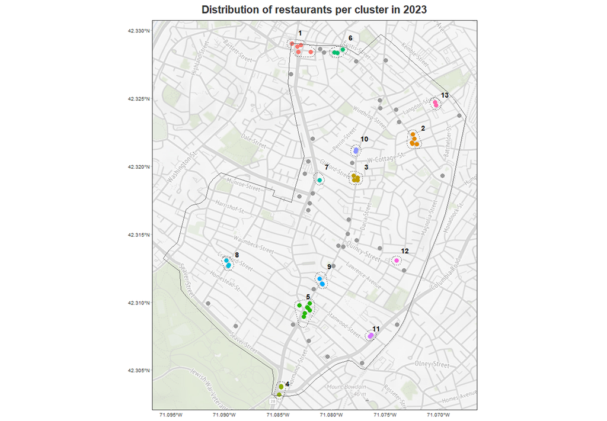

fig.6: distribution of clusters within Common Senses study area

Some clusters within the Common Senses area, such as clusters 1 and 5, stand out due to their high concentration of establishments in relatively small areas. This dense clustering highlights specific hotspots of restaurant activity. On the other hand, clusters like 10, 11, 12, and 13 appear less distinct on the map, as the establishments within them overlap significantly. This overlap suggests that some of these locations host multiple establishments at the same coordinates.

As seen in the following table, cluster number 0, which includes restaurants in the Common SENSES area not part of any specific cluster, shows a range of 30 to 50 restaurants over the past 10 years. We also see that some clusters have between 4 and 10 establishments, while most hover around 3. In certain years, some clusters may have only a single restaurant inspected, which is important to note. Since our measures rely on aggregation, a single restaurant could affect both the calculation and interpretation of the results. Lastly, cluster number 13 began operations in 2023, so we only have data from the last two years for that cluster.

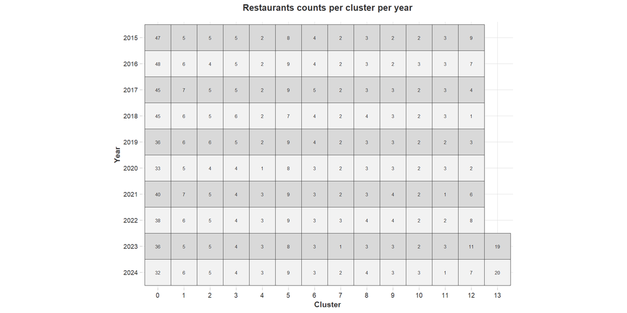

fig.7: raw count of establishment per cluster

**Using these clusters as units of analysis allows us to perform a more granular exploration of restaurant growth within the Common Senses area**, complementing the broader citywide analysis. One of the significant advantages of the clustering process is its ability to uncover insights within individual neighborhoods, offering a finer spatial resolution. For this stage of the analysis, we calculate the adjusted growth rate measure for each cluster, again comparing against the rolling average of the previous five years. In this case, we set the constant *d* to 5, accommodating relative differences in scale among clusters.

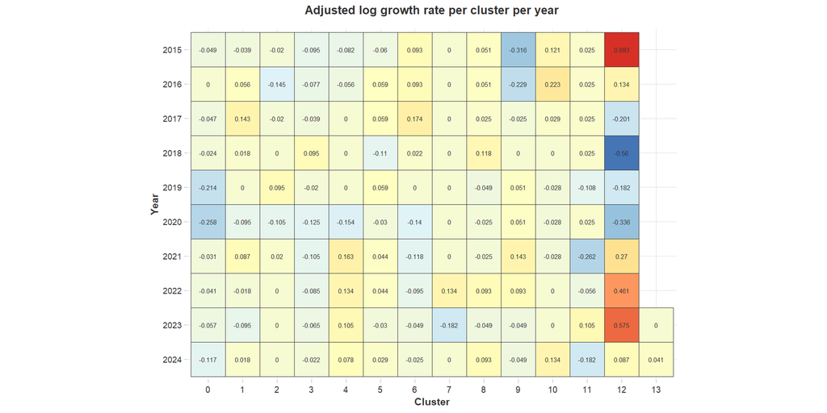

fig.8: measurement score per cluster

**The highest growth rate values are observed in cluster 12, a cluster composed of multiple establishments operating within the same facility**. Similar to cluster 13, these spaces primarily function as food production hubs supporting mobile food vendors, rather than conventional dine-in restaurants. Over the past four years, there has been a notable surge in activity within cluster 12, likely driven by increased demand for shared kitchen facilities. **The concurrent emergence of a similar facility in cluster 13**—a large warehouse with multiple kitchens—further **supports the idea of an unmet demand for such spaces**. This trend suggests that Roxbury has become an attractive area for these types of businesses, potentially due to its relatively low land costs and its central location within Boston, making it accessible for food distribution and vendor operations.

During the pandemic year, we observe that cluster 12 experienced one of the steepest declines in growth rate, potentially due to widespread closures or disruptions in operations for food trucks and businesses reliant on large gatherings of people. Outside of this cluster, the most significant decline is seen in cluster 0, the control group comprising unclustered establishments. **The growth rate for cluster 0 aligns closely with the broader trends observed across Boston**, indicating that these establishments were similarly affected by citywide challenges. Interestingly, **most other clusters in the Common Senses area performed substantially better than the Boston average**, reflecting a level of resilience among local restaurants. However, it is worth noting that clusters in the Common Senses area typically consist of fewer establishments compared to larger, more commercial areas of the city. This smaller scale means that the opening or closing of a single restaurant can have a more pronounced impact on the growth rate. Nonetheless, the adjusted growth rate metric mitigates this effect to some extent, allowing for a more balanced comparison.

# Conclusion

Throughout this post, we have primarily worked with the food establishment inspections dataset. While originally designed to track inspections, this dataset also provides a window into Boston’s evolving urban dynamics when thoughtfully analyzed. In this study, we developed a growth rate metric to assess changes in the number of inspected establishments over time. By comparing inspection counts across years, this measure reveals whether restaurant activity in a given area is increasing, decreasing, or remaining stable. We applied this metric across various spatial aggregations, including neighborhoods and clusters of establishments, to explore trends at both macro and micro levels.

Using this metric, we identified distinctive patterns of growth and decline over the past decade at the neighborhood level, highlighting areas with atypical trends. The measure proved particularly valuable in assessing the impact of the pandemic, a year marked by a significant global downturn in restaurant activity. By comparing neighborhoods, we observed variations in resilience and recovery across the city. Additionally, our analysis uncovered a correlation between growth rate scores in 2020 and the spatial distribution of restaurant clusters relative to downtown Boston, suggesting that some factors indirectly associated to location played a nuanced role in the operation of restaurants during the pandemic. Finally, at the hyperlocal level, we applied the growth rate measure to the Common Senses study area, revealing trends in specialized clusters where multiple establishments operate within shared spaces, such as kitchen facilities.

Overall, the growth rate measure demonstrated its robustness and adaptability across different levels of aggregation. As a standalone metric, it effectively highlighted atypical trends within Boston’s restaurant landscape, shedding light on unique dynamics that might otherwise might go unnoticed. However, as noted in the introduction, it is prudent to interpret these findings within a broader context, recognizing that no single measure can provide a complete understanding of urban dynamics. Instead, this metric should be viewed as a complementary tool that contributes to a richer and more nuanced understanding of Boston’s evolving neighborhoods, alongside other publicly available datasets and analyses.

Future steps in this line of inquiry could involve integrating this measure with variables from other dimensions to uncover deeper connections and causes. For instance, demographic data, such as population size or composition, could help explain why certain areas experienced greater declines during the pandemic. Similarly, datasets like 311 service requests, 911 emergency calls, or street-level activity metrics could offer insights into local challenges that might influence restaurant openings or closures. Additionally, analyzing building permit data as a proxy for public and private investments could provide further context for understanding growth in restaurant numbers, particularly in areas undergoing redevelopment or revitalization. Combining these diverse data sources has the potential to build a more comprehensive narrative of the forces shaping Boston’s restaurant and community landscapes.

# Appendix A

**Appendix A:** Data Dictionary

Existing variables used:

- *resultdttm:* date on which the inspection was carried out.
- *licenseno:* licence number of the food establishment.
- *location:* latitude and longitude of the establishment.

Variables created before the study:

- *cluster:* id of the cluster of the establishment.
- *neighborhood:* neighborhood of the establishment.
- *common_senses:* whether a restaurants is within common senses area.

Variables created in the study:

- *result_year:* year in which the inspection was carried out.
- *count:* number of restaurants for each year and spatial unit pair.
- *base_count:* average number of restaurants in the previous 5 years, for each year and spatial unit pair.
- *gr_score:* growth rate score for each year and spatial unit pair.

# Appendix B

```r
# 0: Import packages
library(ggmap)
library(ggplot2)
library(lubridate)
library(sf)
library(tidyverse)
library(tmap)
library(tmaptools)
```

```r
# 0: Load dataset
filepath <- "path/to/file.csv"
df <- read.csv(filepath)
```

Growth Rate measure construction

*It is noticeable that each time the variable `neighborhood` appears, the same code can be run using `cluster` variable to change the level of aggregation.*

```r
# step 1: extract year
df <- df %>%
  mutate(
    resultdttm = ymd_hms(resultdttm),
    result_year = year(resultdttm)
  )

# step 2: select unique observations
df_gr <- df %>%
  select(neighborhood, licenseno, result_year) %>%
  group_by(neighborhood, licenseno, result_year) %>%
  slice(1) %>% # keep one of each
  ungroup()

# step 3: count establishments by year and spatial unit
df_gr <- df_gr %>%
  group_by(neighborhood, result_year) %>%
  summarise(n = n())

# step 4: calculate a 5-year base
df_gr_base <- data.frame()
for (i in 2015:2024) {
  df_aux <- df_gr %>%
    filter(
      (result_year >= (i - 5)) & (result_year < i)
      )

  df_aux <- df_aux %>%
    group_by(neighborhood) %>%
    summarise(base_n = mean(n)) %>%
    ungroup()

  df_aux$result_year <- i

  df_gr_base <- rbind(df_gr_base, df_aux)
}

# step 5: join base counts into main counts
df_gr <- df_gr %>%
  left_join(df_gr_base, by=c("neighborhood", "result_year")) %>%
  filter(result_year>=2015)

# step 6: metric calculation
d <- 5

df_gr <- df_gr %>%
  mutate(gr_score = (log(n + d) - log(base_n + d)))

#
df_gr[is.na(df_gr$gr_score), "score"] <- 0
```

Growth Rate descriptive statistics

*It is noticeable that each time the variable `neighborhood` appears, the same code can be run using `cluster` variable to change the level of aggregation and the other way around.*

```r
neighs <- read_sf("path/to/neighborhoods.shp")
common_senses <- read_sf("path/to/common_senses.shp")

# fig 1: map
restos_2023 <- df %>%
  filter(year(resultdttm) == 2023) %>%
  group_by(licenseno) %>%
  slice(1) %>%
  filter(!(is.na(latitude) | is.na(longitude))) %>%
  ungroup() %>%
  st_as_sf(coords = c("longitude", "latitude"), crs = 4326, remove = FALSE)

leaflet() %>%
  addProviderTiles() %>%
  addCircleMarkers(data = restos_2023) %>%
  addPolygons(data = neighs) %>%
  addPolygons(data = common_senses) %>%
  addControl(html = "food establishments inspected in 2023 per neighborhood") %>%
  setView(lng = -71.072, lat = 42.313, zoom = 12)

# fig 2: table
gr_table <- ggplot(df_gr, aes(x=neighborhood, y=year_result, fill=gr_score)) +
    geom_tile() +
    geom_text(aes(label=score)) +
    labs(title="Adjusted log growth rate per spatial unit per year",
         y="Year",
         x="Neighborhood") +
    theme_light()

# fig 3: map
# get boston basemap
register_stadiamaps("your-api-key-here")

bbox_boston <- c(
  "left" = -71.195,
  "bottom" = 42.227,
  "right" = -70.955,
  "top" = 42.406
)

basemap_boston <- get_stadiamap(bbox=bbox_boston,
                              maptype="stamen_terrain",
                              zoom=12)

# load spatial units geometries and join the scores for each
neighs_gr <- neighs %>%
  left_join(
    filter(df_gr, result_year==2023), # choose here the desired year to plot
    by="neighborhood"
    )

# plot
ggmap(basemap_boston) +
  geom_sf(data=neighs_gr, aes(fill = gr_score), inherit.aes=FALSE) +
  labs(
    title="Adjusted growth rate per neighborhood in 2023",
    fill="Growth rate"
    ) +
  theme_light()

# fig 4: map
restos_2023_in_clusters <- df %>%
  filter(cluste!=0)

restos_2023_out_clusters <- df %>%
  filter(cluste==0)

leaflet() %>%
  addProviderTiles() %>%
  addCircleMarkers(data = restos_2023_in_clusters) %>%
  addCircleMarkers(data = restos_2023_out_clusters) %>%
  addPolygons(data = neighs) %>%
  addPolygons(data = common_senses) %>%
  addControl(html = "clusters of food establishments inspected in 2023") %>%
  setView(lng = -71.072, lat = 42.313, zoom = 12)

# fig 5: scatterplot
downtown_NAD83 <- neighs %>%
  filter(neighborhood=="Downtown") %>%
  pull(geometry) %>%
  st_centroid() %>%
  st_transform(crs = 2249)

restos_2023 <- restos_2023 %>%
  group_by(cluster) %>%
  summarize(geometry = st_union(geometry), .groups = 'drop') %>%
  ungroup() %>%
  mutate(geometry = st_cast(geometry, "MULTIPOINT")) %>%
  mutate(geometry = st_convex_hull(geometry)) %>%
  mutate(centroid = st_centroid(geometry)) %>%
  st_set_geometry(NULL) %>%
  st_set_geometry("centroid") %>%
  st_transform(crs = 2249) %>%
  mutate(distance_to_downtown = as.numeric(st_distance(centroid, downtown_NAD83)))

restos_2023 <- restos_2023 %>%
  left_join(df_gr, by="cluster")

ggplot(restos_2023, aes(x=distance_to_downtown, y=score_gr)) +
  geom_point() +
  geom_smooth(method=lm, se = TRUE) +
  labs(
    title="Correlation between distance to downtown and growth rate in 2020 per cluster",
    ) +
  theme_light()

# fig 5: correlation
correlations <- Hmisc::rcorr(
  as.matrix(select(restos_2023, distance_to_downtown, score_gr))
  )

# fig 6: map
bbox_cs <- c(
  "left" = -71.195,
  "bottom" = 42.227,
  "right" = -70.955,
  "top" = 42.406
)

basemap_cs <- get_stadiamap(bbox=bbox_cs,
                              maptype="stamen_terrain",
                              zoom=12)

restos_2023_cs <- restos_2023 %>%
  filter(common_senses == 1)

ggmap(basemap_cs) +
  geom_sf(data=restos_2023_cs, aes(color = cluster), inherit.aes=FALSE) +
  labs(
    title="Distribution of restaurants per cluster in 2023"
    ) +
  theme_light()

# fig 7: table
gr_table <- ggplot(df_gr, aes(x=cluster, y=year_result)) +
    geom_tile() +
    geom_text(aes(label=n)) +
    labs(title="Restaurant counts per cluster per year",
         y="Year",
         x="Neighborhood") +
    theme_light()

# fig 8: table
gr_table <- ggplot(df_gr, aes(x=cluster, y=year_result, fill=gr_score)) +
    geom_tile() +
    geom_text(aes(label=score)) +
    labs(title="Adjusted log growth rate per cluster per year",
         y="Year",
         x="Neighborhood") +
    theme_light()
```